# Classification

Elara

2016年5月20日

# logistic regression

$$p(Y=1|X)=\beta_0+\beta_{1}X$$
左边0-1右边不一定0-1,不好
$$logit(p)=log(\frac{p}{1-p})=log(\Omega)=\beta_0+\beta_{1}X$$
左边变成负无穷到正无穷,可以使用,左边叫做对数发生比
其中$p=u_Y$是Y的条件均值(即给定X的取值,Y=1的概率)
$$p(X)=\frac{exp(\beta_0+\beta_{1}X)}{(1+exp(\beta_0+\beta_{1}X))}$$

## example

```r
library("faraway")
data(pima, package="faraway")
head(pima)
```

```
##   pregnant glucose diastolic triceps insulin  bmi diabetes age test
## 1        6     148        72      35       0 33.6    0.627  50    1
## 2        1      85        66      29       0 26.6    0.351  31    0
## 3        8     183        64       0       0 23.3    0.672  32    1
## 4        1      89        66      23      94 28.1    0.167  21    0
## 5        0     137        40      35     168 43.1    2.288  33    1
## 6        5     116        74       0       0 25.6    0.201  30    0
```

```r
b <- factor(pima$test)
head(b)
```

```
## [1] 1 0 1 0 1 0
## Levels: 0 1
```

```r
#模型构建(训练)
#family,二元,link,logit->二元logit模型
m <- glm(b ~ diastolic + bmi, family=binomial(link="logit"), data=pima)
summary(m)
```

```
##
## Call:
## glm(formula = b ~ diastolic + bmi, family = binomial(link = "logit"),
##     data = pima)
##
## Deviance Residuals:
##     Min       1Q   Median       3Q      Max
## -1.9128  -0.9180  -0.6848   1.2336   2.7417
##
## Coefficients:
##              Estimate Std. Error z value Pr(>|z|)
## (Intercept) -3.629553   0.468176  -7.753 9.01e-15 ***
## diastolic   -0.001096   0.004432  -0.247    0.805
## bmi          0.094130   0.012298   7.654 1.95e-14 ***
## ---
## Signif. codes:  0 '***' 0.001 '**' 0.01 '*' 0.05 '.' 0.1 ' ' 1
##
## (Dispersion parameter for binomial family taken to be 1)
##
##     Null deviance: 993.48  on 767  degrees of freedom
## Residual deviance: 920.65  on 765  degrees of freedom
## AIC: 926.65
##
## Number of Fisher Scoring iterations: 4
```

```r
#系数代表的是X变化对与对数发生比的影响
#只用bmi回归因为diastolic不显著,binomial默认是logit不写也行
m.red <- glm(b ~ bmi, family=binomial, data=pima)
summary(m.red)
```

```
##
## Call:
## glm(formula = b ~ bmi, family = binomial, data = pima)
##
## Deviance Residuals:
##     Min       1Q   Median       3Q      Max
## -1.9209  -0.9178  -0.6838   1.2351   2.7244
##
## Coefficients:
##             Estimate Std. Error z value Pr(>|z|)
## (Intercept) -3.68641    0.40896  -9.014  < 2e-16 ***
## bmi          0.09353    0.01205   7.761 8.45e-15 ***
## ---
## Signif. codes:  0 '***' 0.001 '**' 0.01 '*' 0.05 '.' 0.1 ' ' 1
##
## (Dispersion parameter for binomial family taken to be 1)
##
##     Null deviance: 993.48  on 767  degrees of freedom
## Residual deviance: 920.71  on 766  degrees of freedom
## AIC: 924.71
##
## Number of Fisher Scoring iterations: 4
```

```r
#预测
#1 求p(X) Y=1的概率(bmi=32,输入需要用data.frame)
newdata <- data.frame(bmi=32.0)
#type用response,出来的结果是p(x),给定X,Y=1的概率
predict(m.red, type="response", newdata=newdata)
```

```
##         1
## 0.3332689
```

```r
#2 验证p(X)结果正确
E<-exp(-3.68641+0.09353*32)
E/(1+E)
```

```
## [1] 0.333266
```

```r
# According to this model, the probability is about 33.3%. The same calculation for someone in the 90th percentile gives a probability of 54.9%
# 选择bmi的90%分位数(41.5)
newdata <- data.frame(bmi=quantile(pima$bmi, .90))
predict(m.red, type="response", newdata=newdata)
```

```
##       90%
## 0.5486215
```

# exercise

```r
SoftDrink<-read.table(file="C:\\Users\\44180\\Documents\\R-in-SOE\\R\\R-class\\c12\\data\\SoftDrink.txt",header=TRUE)
head(SoftDrink)
```

```
##   Brand Price Calories Fat Vitamin Fruits Age Choice
## 1     1  2.50      463  28       9     13  34      1
## 2     2  5.00      926  57       4      6  22      0
## 3     3  2.28      310  19      13     18  23      1
## 4     4  4.00     1080  66       4      6  40      0
## 5     5  2.50      154   9      15     21  36      1
## 6     6  3.97      221  14       5      7  45      1
```

```r
SoftDrink$Choice<-as.factor(SoftDrink$Choice)
#去掉品牌
Fit<-glm(Choice~.-Brand,data=SoftDrink,family=binomial(link="logit"))
summary(Fit)
```

```
##
## Call:
## glm(formula = Choice ~ . - Brand, family = binomial(link = "logit"),
##     data = SoftDrink)
##
## Deviance Residuals:
##     Min       1Q   Median       3Q      Max
## -2.8461  -0.0433   0.0020   0.1114   3.2400
##
## Coefficients:
##              Estimate Std. Error z value Pr(>|z|)
## (Intercept) 20.851906   8.081177   2.580  0.00987 **
## Price        0.423373   0.327125   1.294  0.19559
## Calories    -0.025519   0.008767  -2.911  0.00361 **
## Fat         -0.080466   0.048667  -1.653  0.09825 .
## Vitamin     -0.940737   0.460753  -2.042  0.04118 *
## Fruits       0.376950   0.159685   2.361  0.01825 *
## Age          0.013747   0.015796   0.870  0.38415
## ---
## Signif. codes:  0 '***' 0.001 '**' 0.01 '*' 0.05 '.' 0.1 ' ' 1
##
## (Dispersion parameter for binomial family taken to be 1)
##
##     Null deviance: 403.427  on 291  degrees of freedom
## Residual deviance:  79.962  on 285  degrees of freedom
## AIC: 93.962
##
## Number of Fisher Scoring iterations: 8
```

```r
#只留下calories和fruits
Fit<-glm(Choice~.-Brand-Price-Fat-Age-Vitamin,data=SoftDrink,family=binomial(link="logit"))
summary(Fit)
```

```
##
## Call:
## glm(formula = Choice ~ . - Brand - Price - Fat - Age - Vitamin,
##     family = binomial(link = "logit"), data = SoftDrink)
##
## Deviance Residuals:
##     Min       1Q   Median       3Q      Max
## -3.6579  -0.1009   0.0019   0.1018   2.9622
##
## Coefficients:
##              Estimate Std. Error z value Pr(>|z|)
## (Intercept)  8.577449   3.439845   2.494   0.0126 *
## Calories    -0.017091   0.003644  -4.690 2.74e-06 ***
## Fruits       0.354141   0.186476   1.899   0.0575 .
## ---
## Signif. codes:  0 '***' 0.001 '**' 0.01 '*' 0.05 '.' 0.1 ' ' 1
##
## (Dispersion parameter for binomial family taken to be 1)
##
##     Null deviance: 403.427  on 291  degrees of freedom
## Residual deviance:  88.498  on 289  degrees of freedom
## AIC: 94.498
##
## Number of Fisher Scoring iterations: 8
```

```r
coef(Fit)
```

```
## (Intercept)    Calories      Fruits
##   8.5774486  -0.0170909   0.3541405
```

```r
#卡路里提高一单位,可以让对数发生比平均减少0.017单位
exp(coef(Fit))
```

```
##  (Intercept)     Calories       Fruits
## 5310.5389762    0.9830543    1.4249554
```

```r
#卡路里提高一单位,可以让发生比(优势比或购买意向)变成原来的0.9830543
```

# cluster analysis

## Hierarchical Clustering

系统聚类 层次聚类,点之间用欧式距离

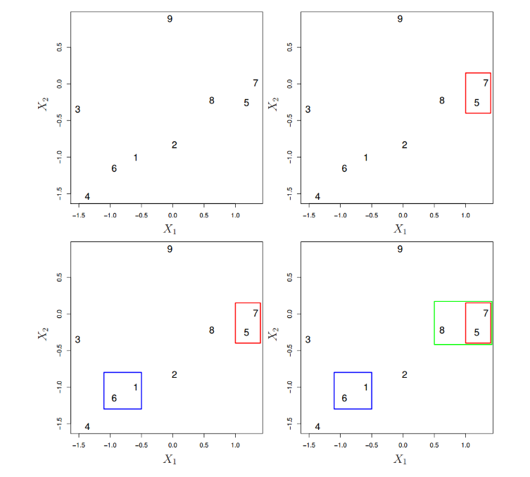

### Interpreting a Dendrogram

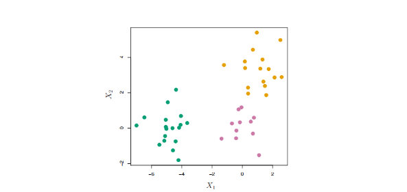

分类的类数不同

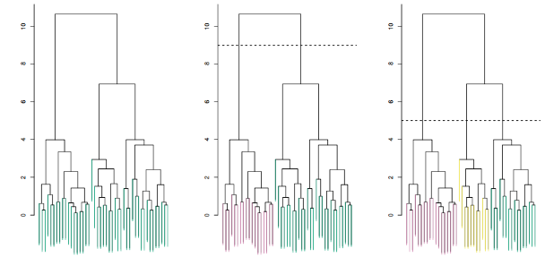

### Linkage (distance) between Cluster Pairs

类间距离 1. Nearest neighbor (single linkage).最小距离法  
If you use the nearest neighbor method to form clusters, the distance between two clusters is defined as the smallest distance between two cases in the different clusters.  
2个类中距离最近的元素的距离作为类间距离  
2. Furthest neighbor (complete linkage).最大距离法  
If you use a method called furthest neighbor (also known as complete linkage), the distance between two clusters is defined as the distance between the two furthest points.  
2个类中距离最远的元素的距离作为类间距离  
3. Average method.平均法  
Mean intercluster dissimilarity. Compute all pairwise dissimilarities between the observations in cluster A and the observations in cluster B, and record the average of these dissimilarities.  
计算2个类中所有点组合的距离,取平均  
4. Centroid method.中心法  
This method calculates the distance between two clusters as the sum of distances between cluster means for all of the variables. In the centroid method, the centroid of a merged cluster is a weighted combination of the centroids of the two individual clusters, where the weights are proportional to the sizes of the clusters. One disadvantage of the centroid method is that the distance at which clusters are combined can actually decrease from one step to the next. This is an undesirable property because clusters merged at later stages are more dissimilar than those merged at early stages.  
计算各个类中各个变量的均值,用这些均值在不同类之间的距离和作为类间距离.已经合并的类用他们的均衡根据类大小加权均值作为合并类的均值.  
缺点:距离随着类越来越大会缩减.

### example

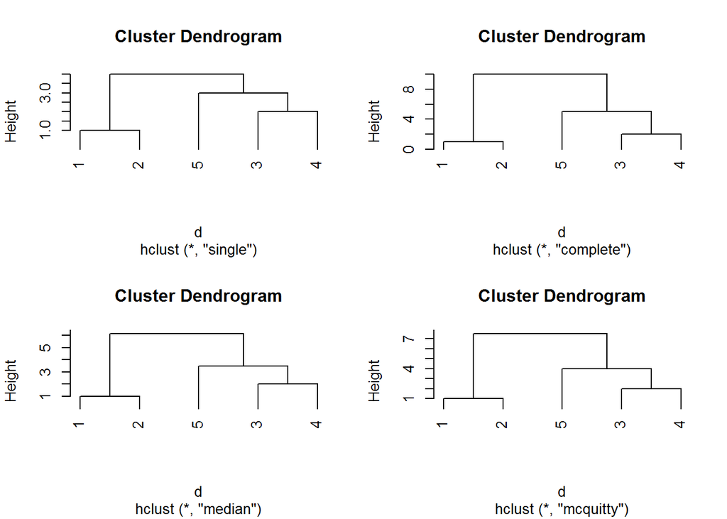

```r
# 1
#Calculate
x<-c(1,2,6,8,11); dim(x)<-c(5,1)
d<-dist(x)
hc1<-hclust(d, "single"); hc2<-hclust(d, "complete")
hc3<-hclust(d, "median"); hc4<-hclust(d, "mcquitty")
#Plot
opar <- par(mfrow = c(2, 2))
plot(hc1,hang=-1); plot(hc2,hang=-1)
plot(hc3,hang=-1); plot(hc4,hang=-1)
```

```r
par(opar)

# 2
#各省数据
PoData<-read.table(file="C:\\Users\\44180\\Documents\\R-in-SOE\\R\\R-class\\c12\\data\\PollutionData1.txt",header=TRUE)
#只拿数据部分
CluData<-PoData[,2:7]
head(CluData)
```

```
##      x1    x2     x3     x4     x5    x6
## 1 21.76 15.01  12.23   0.02  10.69  3.09
## 2  7.47  4.19   4.80   0.00  11.44  7.68
## 3 21.92 43.49  69.43   9.40 100.00 45.79
## 4 13.79 58.94  93.45 100.00  44.60 15.04
## 5  7.44 37.97  69.87   2.16  37.87  9.02
## 6 27.90 36.64 100.00   1.08  49.84 35.21
```

```r
###Hierarchical Clustering层次聚类
#计算欧式距离矩阵
DisMatrix<-dist(CluData,method = "euclidean")#欧式距离
DisMatrix
```

```
##             1          2          3          4          5          6
## 2   19.952754
## 3  118.196982 123.749485
## 4  140.992004 148.492702 114.476383
## 5   69.520432  77.975639  74.195160 103.393804
## 6  103.801107 112.991392  60.945814 104.683989  46.460314
## 7   32.378754  38.382130 103.039961 125.779139  46.531875  78.200902
## 8   33.795568  41.728767  98.819546 123.314174  42.275796  73.794294
## 9   33.119221  49.206433  97.369147 127.885795  56.711525  80.490176
## 10 108.851119 110.240325 103.507928 165.438376 119.797932 113.843611
## 11  77.739312  75.170174 103.866556 157.250997 101.289584 109.199067
## 12  31.356113  35.271654  94.138209 133.141383  59.727368  84.715172
## 13  49.644625  46.633998 105.385220 144.520382  79.563086  97.057944
## 14  24.408163  23.534736 111.595150 140.218007  71.500550 100.949841
## 15  98.827582 106.826756  46.215954 121.756838  70.207407  58.938573
## 16  63.254914  71.097603  73.398020 126.069817  62.090139  69.743344
## 17  36.010704  44.627350  98.915342 134.955280  68.763311  89.833165
## 18  46.895973  57.879844  92.043089 120.727500  58.696453  76.827187
## 19 121.107130 127.301011 132.251688 181.026798 141.853013 133.425198
## 20  68.226706  66.830723 106.055411 151.934057  95.417859 106.398241
## 21  26.141444  12.475051 135.881088 155.374966  87.093233 122.896452
## 22  50.163035  56.487378  97.000605  97.278848  54.563504  81.417878
## 23  88.085472  95.230704  68.325060  74.851434  64.706896  65.650299
## 24  94.822691 106.471575 109.205917 105.369998  71.053970  97.246198
## 25  28.940864  33.037963 104.033079 116.086238  56.206486  90.544268
## 26  31.193905  16.945663 139.142078 156.279411  88.858611 125.875678
## 27  26.709861  31.076124 103.628223 122.354808  53.625158  86.490430
## 28  18.834511  21.385547 113.041924 131.220701  60.532764  98.586851
## 29  24.223563  11.717124 128.491295 147.941544  77.002856 113.487621
## 30  21.845640   6.349520 124.802157 146.622957  76.481468 112.582551
## 31  33.039322  40.779036 104.237358 112.255472  46.844811  83.242430
##             7          8          9         10         11         12
## 2
## 3
## 4
## 5
## 6
## 7
## 8    5.631119
## 9   34.871477  31.749249
```

[output cut: 100 more lines]

```
## 17
## 18
## 19
## 20
## 21
## 22
## 23
## 24
## 25
## 26  43.653439
## 27  12.029618  42.749065
## 28  18.104950  30.829092  16.944506
## 29  34.640087  12.675390  32.313095  21.505934
## 30  31.505184  14.987938  29.403019  18.626368   8.627746
## 31  14.854360  49.375736  15.697493  21.706667  39.121500  38.324885
```

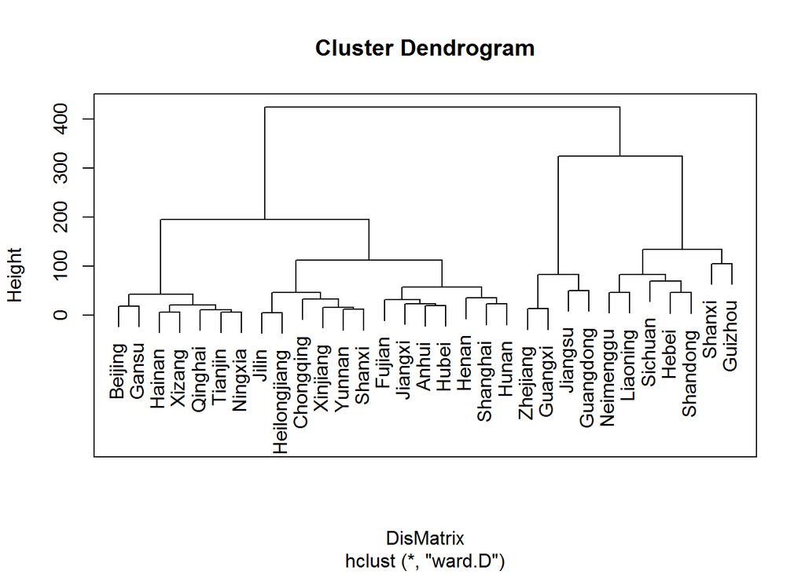

```r
#用ward.D方法聚类
CluR<-hclust(d=DisMatrix,method="ward.D")
#Graph_1
plot(CluR,labels=PoData[,1])
box()#图加框
```

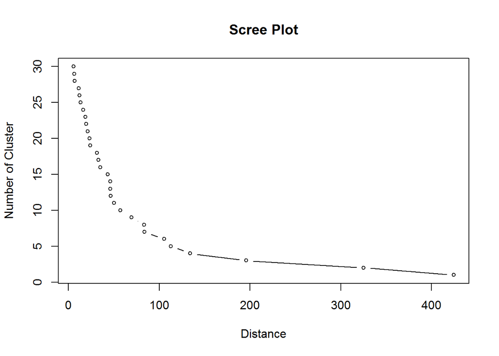

```r
#Graph_2 类内距离与剩余类数的关系.例如类内距离200左右,归为3类,差值代表再多合并一次(减少一类)所要增加的类内距离.
plot(CluR$height,30:1,type="b",cex=0.7,xlab="Distance",ylab="Number of Cluster",main="Scree Plot")
```

```r
# 3
# 画type-elements图
PoData$memb<-cutree(CluR,k=4)
View(PoData)
table(PoData$memb)
```

```
##
##  1  2  3  4
##  7  7 13  4
```

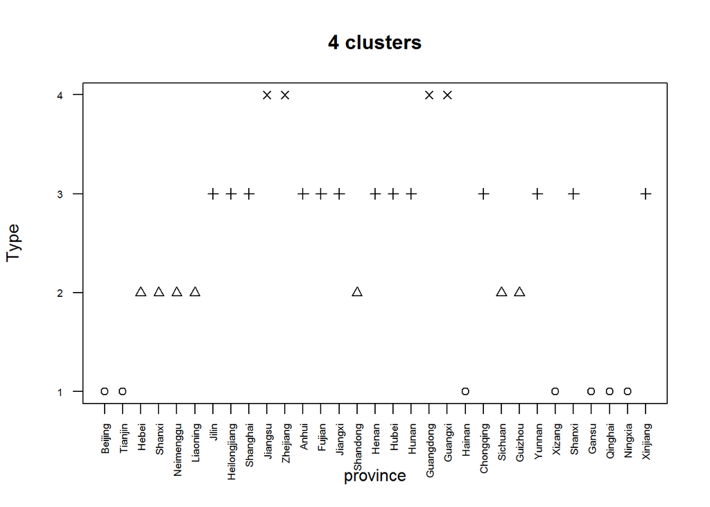

```r
plot(PoData$memb,pch=PoData$memb,ylab="Type",xlab="province",main="4 clusters",axes=FALSE)
par(las=2)
axis(1,at=1:31,labels=PoData$province,cex.axis=0.6)
axis(2,at=1:4,labels=1:4,cex.axis=0.6)
box()
```

## K-means Clustering

要先分配类别个数K

### 选定类中心

1. 经验选择法
2. 最大最小法:选择观测点中距离最远的两个点作为类中心

### 聚类

1. 计算每个观测点到类中心的距离
2. 距离哪个类中心近,就归类到那一类
3. 重新根据分类好的类别,分别计算各自的类中心
4. 按照新的类中心重复1,2,3步
5. 直到第N次类中心和N-1次类中心距离几乎为0,说明完成收敛

### example1

```r
# 生成2列100对正态分布数据N(0,0.09)和N(1,0.09),分成2组,每组50对
x <- rbind(matrix(rnorm(100, sd = 0.3), ncol = 2),
matrix(rnorm(100, mean = 1, sd = 0.3), ncol = 2))
# K均值聚类(2类)
cl <- kmeans(x, 2)
cl
```

```
## K-means clustering with 2 clusters of sizes 51, 49
##
## Cluster means:
##         [,1]       [,2]
## 1 0.07981486 0.00634375
## 2 1.14043176 1.00238234
##
## Clustering vector:
##   [1] 1 1 1 1 1 1 1 1 1 1 1 1 1 1 1 1 1 1 1 1 1 1 1 1 1 1 1 1 1 1 1 1 1 1 1
##  [36] 1 1 1 1 1 1 1 1 1 1 1 1 1 1 1 2 2 2 2 2 2 2 2 2 2 2 2 2 2 2 2 2 2 2 2
##  [71] 2 2 2 2 2 2 2 2 2 2 2 2 2 2 2 2 2 2 2 2 2 2 2 2 2 2 1 2 2 2
##
## Within cluster sum of squares by cluster:
## [1] 10.333741  9.520007
##  (between_SS / total_SS =  72.7 %)
##
## Available components:
##
## [1] "cluster"      "centers"      "totss"        "withinss"
## [5] "tot.withinss" "betweenss"    "size"         "iter"
## [9] "ifault"
```

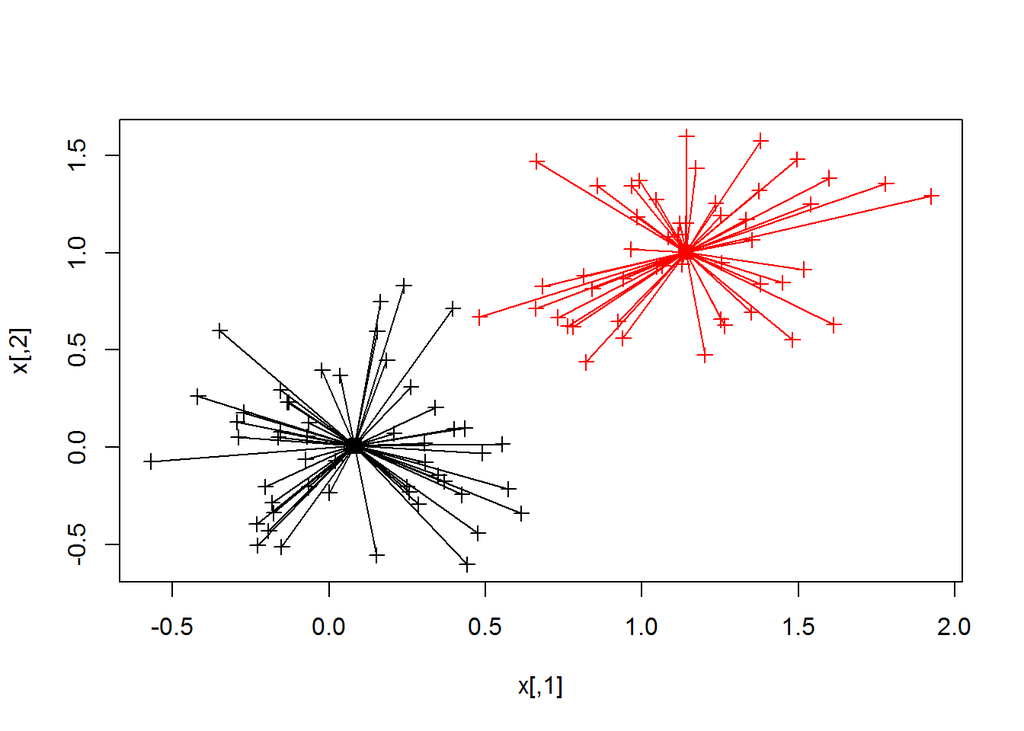

```r
# 分色标点
plot(x, col = cl$cluster, pch=3, lwd=1)
# 标识类中心
points(cl$centers, col = 1:2, pch = 7, lwd=3)
#连接类中心和各个点
segments( x[cl$cluster==1,][,1], x[cl$cluster==1,][,2],cl$centers[1,1], cl$centers[1,2])
segments( x[cl$cluster==2,][,1], x[cl$cluster==2,][,2],cl$centers[2,1], cl$centers[2,2],
col=2)
```

### example2

```r
# 鸢尾花数据
newiris <- iris
head(newiris)
```

```
##   Sepal.Length Sepal.Width Petal.Length Petal.Width Species
## 1          5.1         3.5          1.4         0.2  setosa
## 2          4.9         3.0          1.4         0.2  setosa
## 3          4.7         3.2          1.3         0.2  setosa
## 4          4.6         3.1          1.5         0.2  setosa
## 5          5.0         3.6          1.4         0.2  setosa
## 6          5.4         3.9          1.7         0.4  setosa
```

```r
# 去掉种类数据
newiris$Species <- NULL
# 3类K均值聚类
kc <- kmeans(newiris, 3)
names(kc)
```

```
## [1] "cluster"      "centers"      "totss"        "withinss"
## [5] "tot.withinss" "betweenss"    "size"         "iter"
## [9] "ifault"
```

```r
#显示结果
kc$cluster
```

```
##   [1] 2 2 2 2 2 2 2 2 2 2 2 2 2 2 2 2 2 2 2 2 2 2 2 2 2 2 2 2 2 2 2 2 2 2 2
##  [36] 2 2 2 2 2 2 2 2 2 2 2 2 2 2 2 3 3 1 3 3 3 3 3 3 3 3 3 3 3 3 3 3 3 3 3
##  [71] 3 3 3 3 3 3 3 1 3 3 3 3 3 3 3 3 3 3 3 3 3 3 3 3 3 3 3 3 3 3 1 3 1 1 1
## [106] 1 3 1 1 1 1 1 1 3 3 1 1 1 1 3 1 3 1 3 1 1 3 3 1 1 1 1 1 3 1 1 1 1 3 1
## [141] 1 1 3 1 1 1 3 1 1 3
```

```r
#行名是真实类,列名是k均值分类,每个数字表示行的真实类被分到第k类的数量
table(iris$Species, kc$cluster)
```

```
##
##               1  2  3
##   setosa      0 50  0
##   versicolor  2  0 48
##   virginica  36  0 14
```

```r
#重复聚类结果不同
kc <- kmeans(newiris, 3)
table(iris$Species, kc$cluster)
```

```
##
##               1  2  3
##   setosa      0 50  0
##   versicolor 48  0  2
##   virginica  14  0 36
```

# example3

```r
#污染数据k均值聚类
PoData<-read.table(file="C:\\Users\\44180\\Documents\\R-in-SOE\\R\\R-class\\c12\\data\\PollutionData1.txt",header=TRUE)
CluData<-PoData[,2:7]
set.seed(12345)
CluR<-kmeans(x=CluData,centers=4,nstart=4,iter.max=10)
CluR$size
```

```
## [1]  4 19  2  6
```

```r
CluR$centers
```

```
##         x1       x2       x3       x4       x5       x6
## 1 53.39250  8.33500  7.97000  1.42250 36.78750 83.69250
## 2 15.06895 15.09263 20.43263  5.31000 13.37316 16.45105
## 3 11.48000 79.47000 69.43000 59.88000 33.07000  9.62000
## 4 26.91000 39.77167 63.68333 10.42833 56.67667 40.70000
```

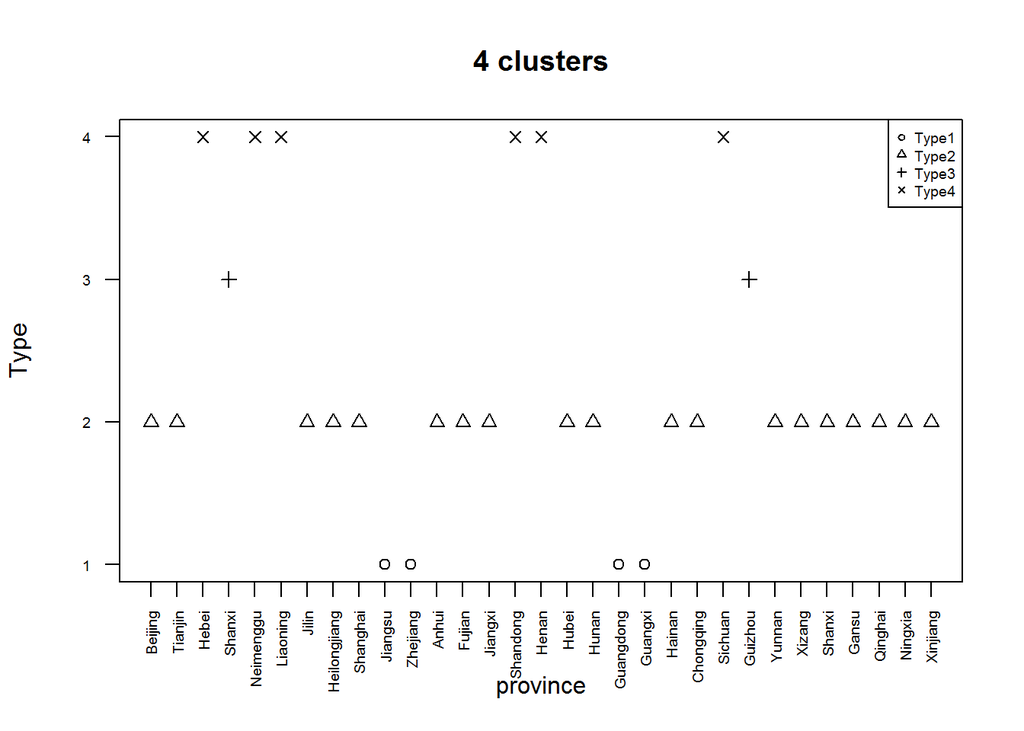

```r
#绘图
# opar<-par(no.readonly = TRUE)
# par(mfrow=c(2,1))
#Graph_1 type-elements graph
PoData$CluR<-CluR$cluster
plot(PoData$CluR,pch=PoData$CluR,ylab="Type",xlab="province",main="4 clusters",axes=FALSE)
par(las=2)
axis(1,at=1:31,labels=PoData$province,cex.axis=0.6)
axis(2,at=1:4,labels=1:4,cex.axis=0.6)
box()
legend("topright",c("Type1","Type2","Type3","Type4"),pch=1:4,cex=0.6)
```

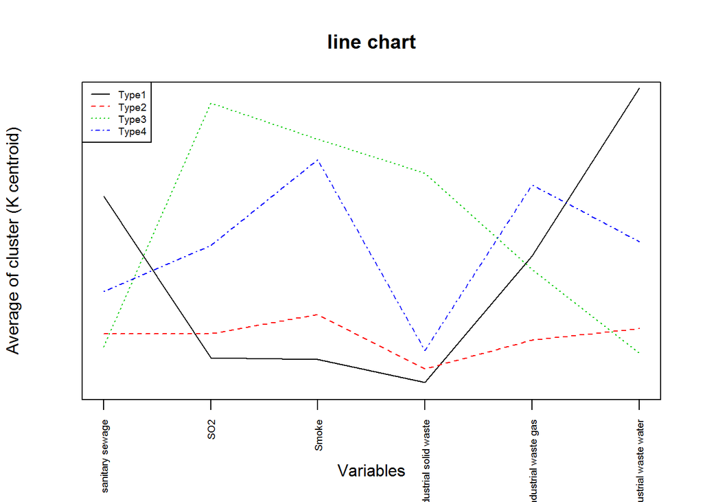

```r
#Graph_2 每类在各种排放物的排放量上的特点
plot(CluR$centers[1,],type="l",ylim=c(0,82),xlab="Variables",ylab="Average of cluster (K centroid)",main="line chart",axes=FALSE)
axis(1,at=1:6,labels=c("sanitary sewage","SO2","Smoke","Industrial solid waste",
"industrial waste gas","industrial waste water"),cex.axis=0.6)
box()
lines(1:6,CluR$centers[2,],lty=2,col=2)
lines(1:6,CluR$centers[3,],lty=3,col=3)
lines(1:6,CluR$centers[4,],lty=4,col=4)
legend("topleft",c("Type1","Type2","Type3","Type4"),lty=1:4,col=1:4,cex=0.6)
```